# Plotting in R

### 2.5.2 Adding colors and legends

Still, our plot is really black and white, and could use some color. The color argument is simply `col`.

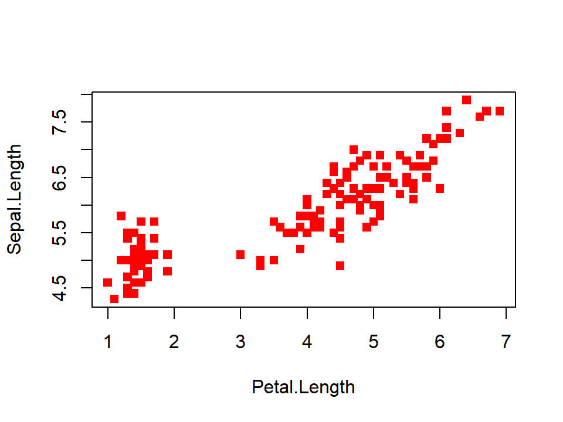

```r
plot(Sepal.Length ~ Petal.Length, data = iris, pch = 15, col = "red")
```

There are a ton of available colors, and I recommend googling “R colors” to see what options you have. You can also provide hexadecimal (e.g. `col = "#eda611"`) or rgb colors (e.g. `col = rgb(132, 77, 73 )`), if you want to be really precise.

The red color makes our plot prettier, but not more informative. A good approach here would be to color the points by species. You can do this by providing a vector instead of a color name. The syntax here is rather weird, and just something you have to remember[^2].

*Edit August 27th 2020: With R version 4.0 onwards, strings aren’t automatically converted to factors when importing data. In practice this means that you need to turn* `iris$species` *into a factor variable before plotting (or using* `stringsAsFactors = TRUE` *on import). This is reflected in the updated code below:*

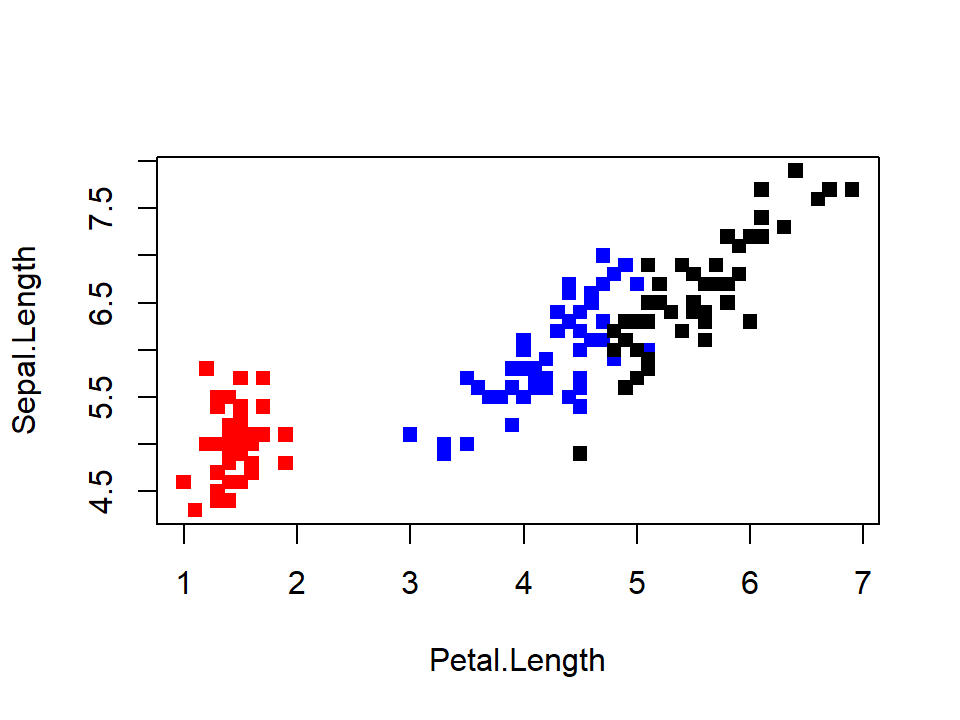

Figure 2.8: A plot with color-coded species, but which is which?

```r
iris$Species <- factor(iris$Species)

plot(Sepal.Length ~ Petal.Length, data = iris, pch = 15, col = c("red", "blue", "black")[iris$Species])
```

Now you have colors, but no way of telling which is which. To see this you have to add a legend. Legends in base R plotting are manual, and have to be added to the plot after creating it, with the `legend()` function.

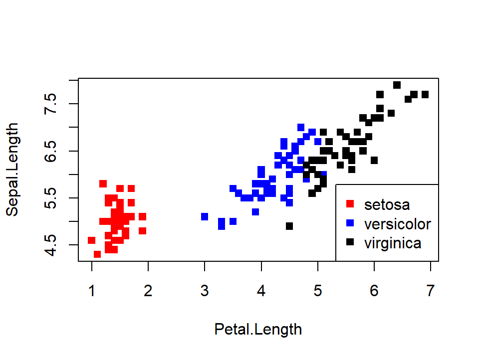

Figure 2.9: With a legend you can see which color is which species!

```r
plot(Sepal.Length ~ Petal.Length, data = iris, pch = 15, col = c("red", "blue", "black")[iris$Species])
legend("bottomright", legend = levels(iris$Species), col = c("red", "blue", "black"), pch = 15)
```

As a side note, you can apply this same procedure for `pch` and `lty` as well if you want to.

#### 2.5.2.1 A note about color choice

When you choose colors for your plot, remember that not all people can distinguish all colors! Red-green colorblindness is quite common, so you should never distinguish your points using these two colors. See e.g. [this page](https://venngage.com/blog/color-blind-friendly-palette/#4) for some tips on being color blind friendly.

### 2.5.3 Modifying axis labels, title, etc.

Our plot is nearly good, but we should modify our labels and create a title for it to be more informative! This is done with the `main`, `xlab` and `ylab` arguments of the `plot()` function.

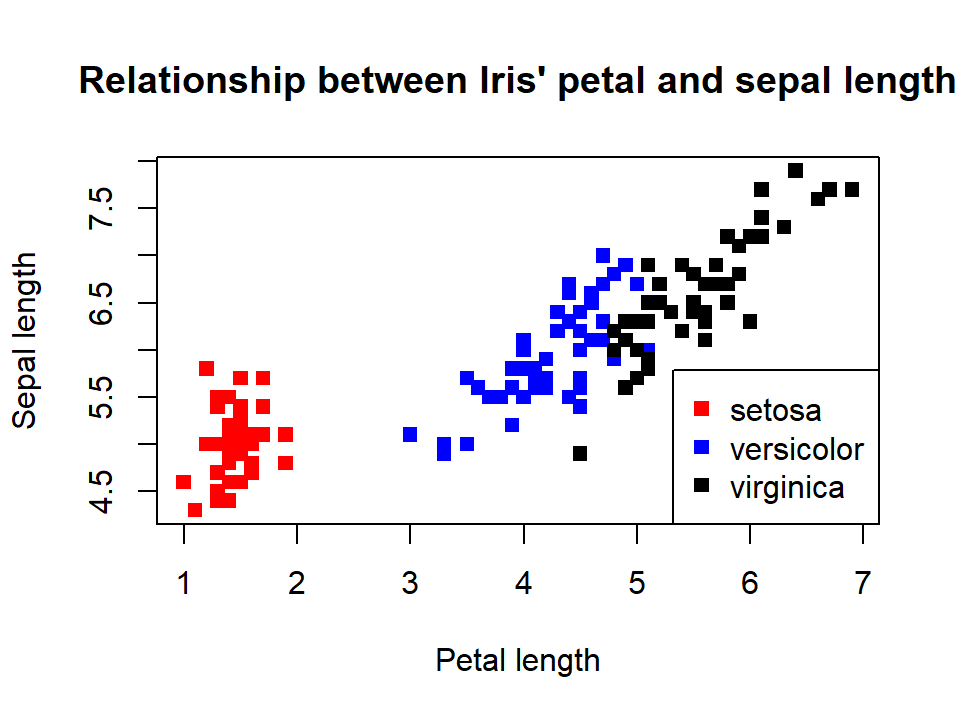

Figure 2.10: Our finished plot!

```r
plot(Sepal.Length ~ Petal.Length,
     data = iris,
     pch = 15,
     col = c("red", "blue", "black")[iris$Species],
     main = "Relationship between Iris' petal and sepal length",
     xlab = "Petal length",
     ylab = "Sepal length")
legend("bottomright", legend = levels(iris$Species), col = c("red", "blue", "black"), pch = 15)
```

**Tip:** Notice how I have placed the arguments on separate lines for better readability in the example above. As long as you have an unclosed parenthesis R will not care about the line breaks, so I recommend this approach whenever you use many arguments of a function.

The arguments `xlim` and `ylim` modifies our view of the x and y-axis respectively. If we wanted to focus on just *I. versicolor* and *I. virginica* we could use these arguments[^3]:

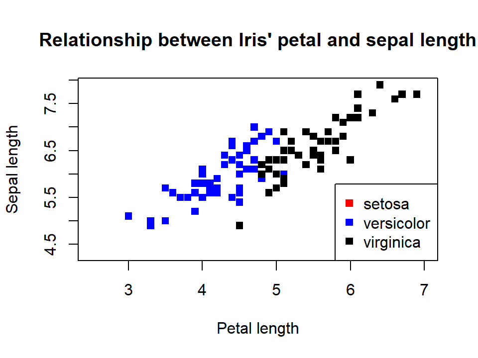

Figure 2.11: Our plot, zoomed in on versicolor and virginica

```r
plot(Sepal.Length ~ Petal.Length,
     data = iris,
     pch = 15,
     col = c("red", "blue", "black")[iris$Species],
     main = "Relationship between Iris' petal and sepal length",
     xlab = "Petal length",
     ylab = "Sepal length",
     xlim = c(2.5, 7))
legend("bottomright", legend = levels(iris$Species), col = c("red", "blue", "black"), pch = 15)
```

# 3 ggplot2

ggplot2 is a different system altogether for plotting in R. Some of the benefits are:

- Looks pretty straight away
- It never guesses for you what visualisation you want to make, you have to tell it what to do
- Automatic generation of legend, making it harder to mess up
- A lot of default colorblind friendly palettes
- Easy to map variables to e.g. color, point type etc.

Some drawbacks are:

- Pretty visuals may blind you to problems with your visualisation
- It never guesses for you what visualisation you want to make, you have to tell it what to do
- Your data always has to be contained in a data frame (although it mostly will be anyway)
- It’s troublesome to use in functions
- Modifying graphical parameters can sometimes be a hassle, be prepared for spending a lot of time on stackoverflow!

ggplot2 will not be taught in this course, but I recommend [chapter 3](https://r4ds.had.co.nz/data-visualisation.html) of [R for Data Science](https://r4ds.had.co.nz/) if you want to know more, that’s how I learned this!

To see the potential of ggplot, here is how easy it is to make the same graph as we made in base plot:

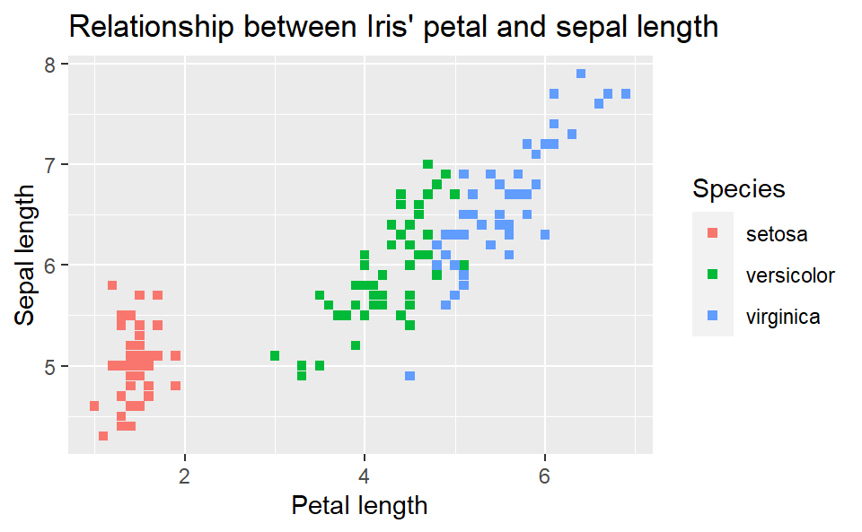

```r
library(ggplot2)
ggplot(iris, aes(Petal.Length, Sepal.Length, col = Species)) +
  geom_point(pch = 15) +
  labs(title = "Relationship between Iris' petal and sepal length",
     x = "Petal length",
     y = "Sepal length")
```

[^1]: I wasn’t able to find any way to plot just the points without the boxplot, it seems base R plotting doesn’t have this functionality. If you want to plot just the points I recommend ggplot2.
[^2]: I’d argue that this kind of plotting is a lot easier in ggplot2 (see section 3)
[^3]: A cleaner approach to this would probably be to exclude *I. setosa* from our data before plotting